# Colorado Home & Commercial PV Trends

Jake Schefrin

## What is this?

I recently read an [article](https://www.theamericanconsumer.org/wp-content/uploads/2014/08/ConsumerGram_Net-Metering.pdf) talking about the costs from home solar incentive programs. The article makes some good points about what these costs are and who these programs benefit. However internal questions were raised, namely why only do a cost analysis when there is easily available data to do a benefit one? Why not do a state by state breakdown vs using the national averages? The authors also neglected to assign a dollar value to the costs. My goal is to try and put a dollar amount on the cost of home and commercial solar programs in Colorado, as well as the benefits resulting from fewer carbon emissions. I’ve been working on this off and on for a while, but I wanted to share some of the visuals from the data in the meantime, as well as some of the data issues with Colorado EIA data.

## Data

All data comes from the [Energy Information Administration](https://www.eia.gov/) and the [Colorado Information Marketplace](https://data.colorado.gov/Environment/Electricity-Net-Metering-in-Colorado/y23n-tr7i). Data is from 2012 to 2019. The data set did not include all utilities in Colorado. Data was available for the following utilities: Public Service Co of Colorado (Xcel Energy), Black Hills Colorado Electric, Intermountain Rural Electric Assn, Moon Lake Electric Assn, Poudre Valley Rural Electric Assn, San Luis Valley REC, United Power, City of Colorado Springs, and City of Fort Collins. There are some data entry errors so not all graphs include all utilities. I have uploaded the csv from the Colorado Information Marketplace onto my GitHub, as well as the R code used to clean and prep the data. A link to the repository is [here](https://github.com/bschefrin/co_solar_project). Locations of the utilities in Colorado can be found on the map below. It’s a moderately easier version of Where’s Waldo.

[figure not shown]

## Home Solar

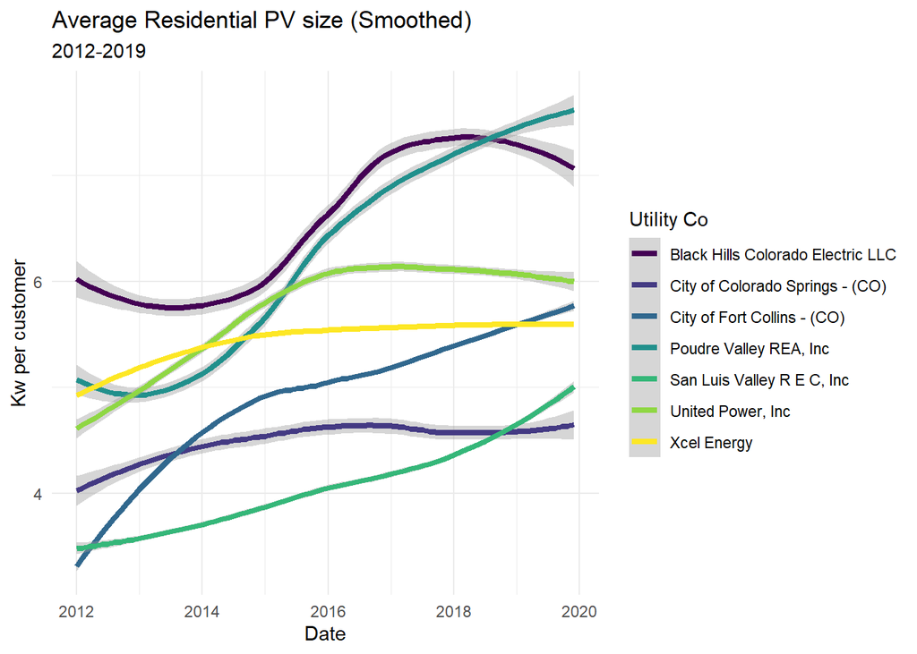

The solar Kw per customer is gradually increasing for most utilities. I found it interesting that Xcel didn’t increase, though that could be because of constraints in available space for solar panels. Colorado Springs also remained pretty consistent. I found [this](https://www.csu.org/Documents/RenewableEnergyRebateFactSheet.pdf?csf=1&e=neSDSb) on the Colorado Springs Utility website stating that a 4 Kw PV system was enough for most houses and their customers appear to be roughly following that guideline. Nationally the average is 5 Kw but with a lot of variation between regions.

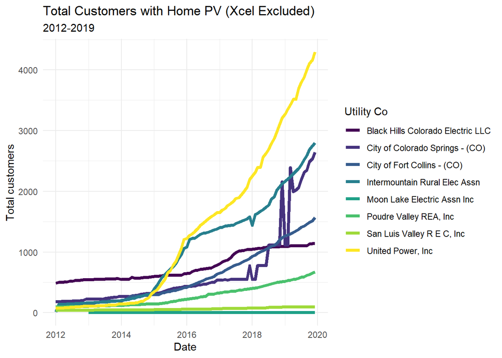

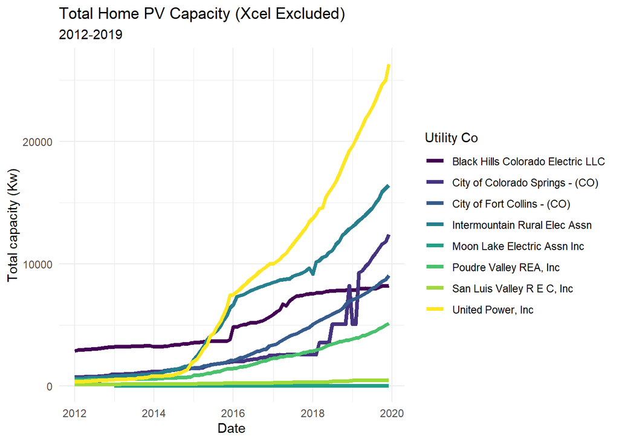

Capacity and customers for United Power, Colorado Springs, and Intermountain Rural Electric rise dramatically over the span of the data while other utilities like Black Hills Colorado Electric do not. I did some digging on their respective websites and found that Black Hills does not have an opt in solar purchasing program for their customers while the first three do. I could not find if the EIA includes these opt in customers in their net metering data for customers and capacity, or if this is more people building home solar.

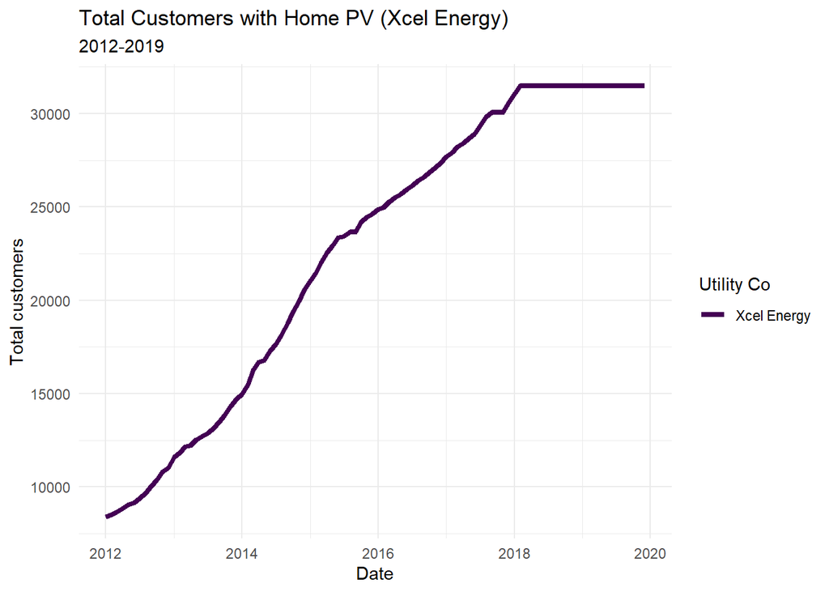

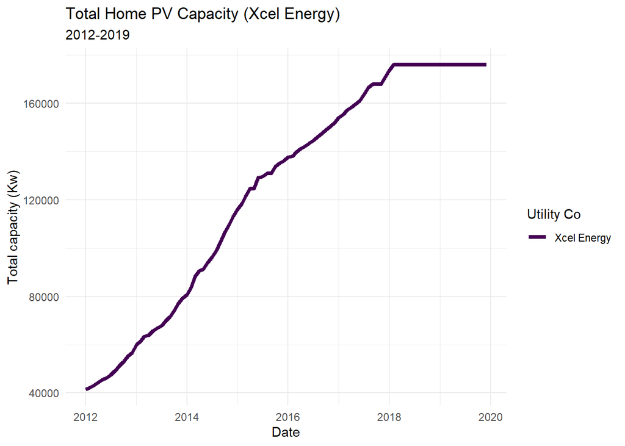

One of the glaring issues with the data is that Xcel appears to have stopped being collected in 2018. Given its trend over time I find it highly suspect that they have reached their ceiling with both customers and capacity at the beginning of 2018.

## Commercial Solar

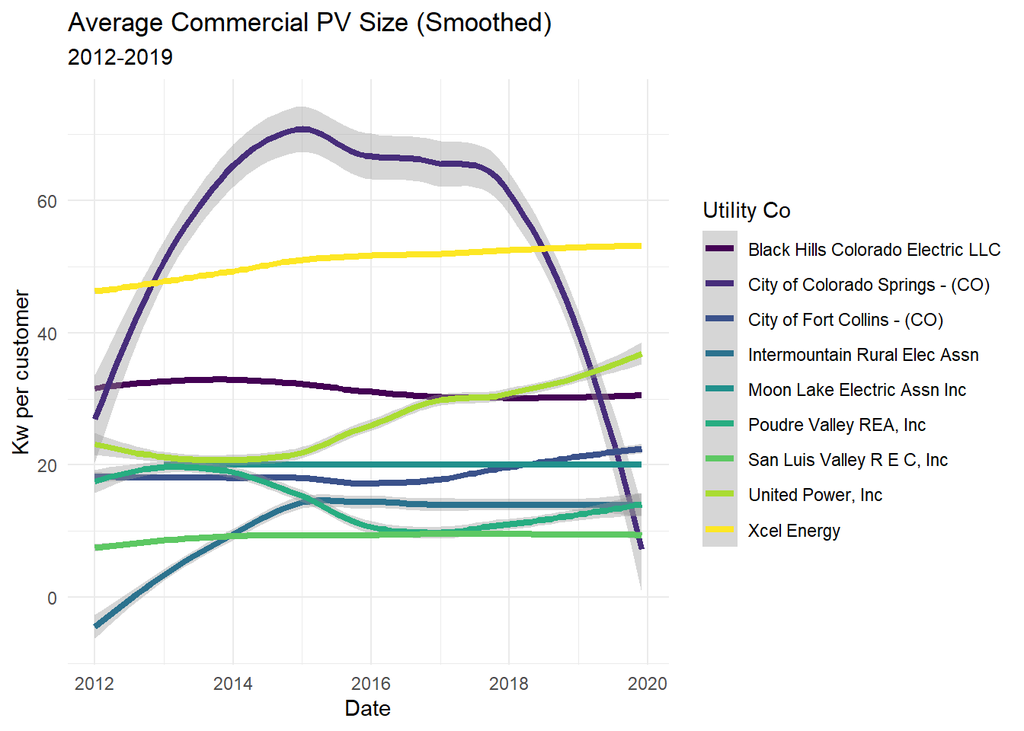

Commercial PV per customer Kw remains relatively consistent for utilities except Colorado Springs. More on that below

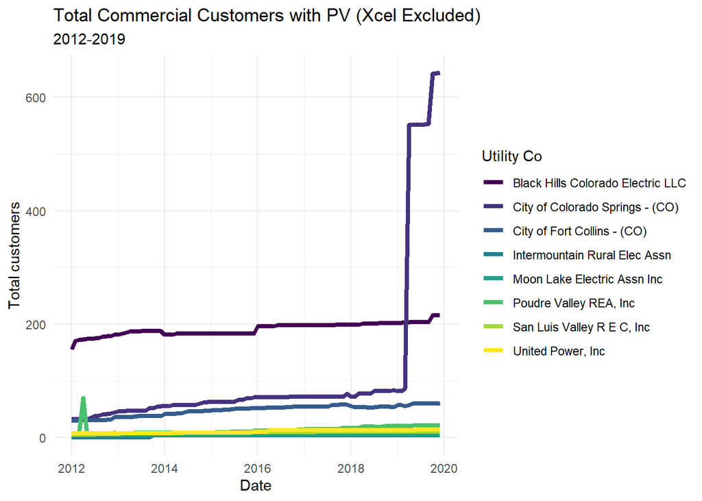

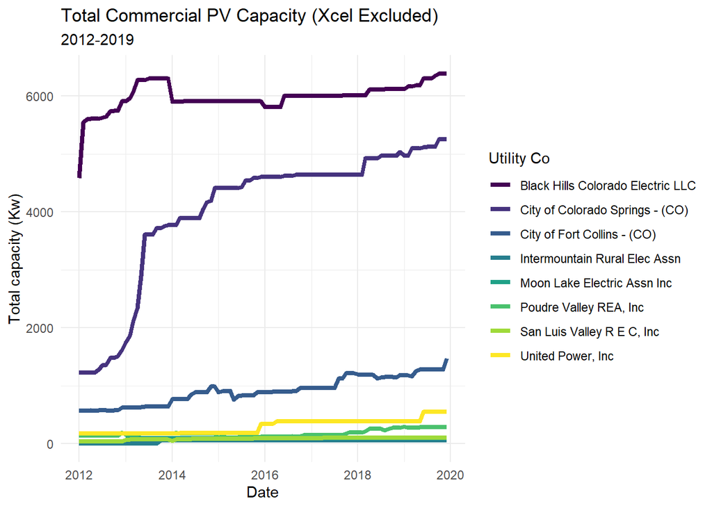

My best guess for the Colorado Springs spike (and drop in Kw per customer) would be the way they collected and/or classified commercial customer data. Capacity jumped well before the customer spike so it is difficult to say what happened here.

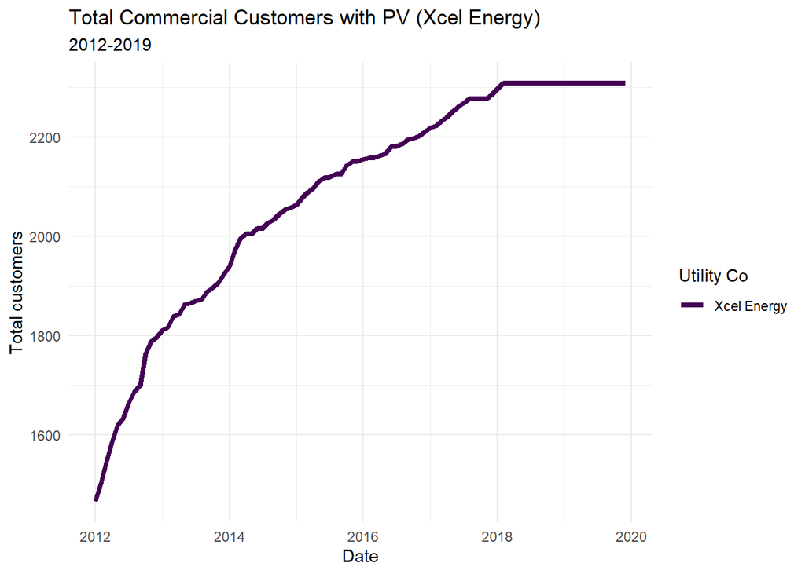

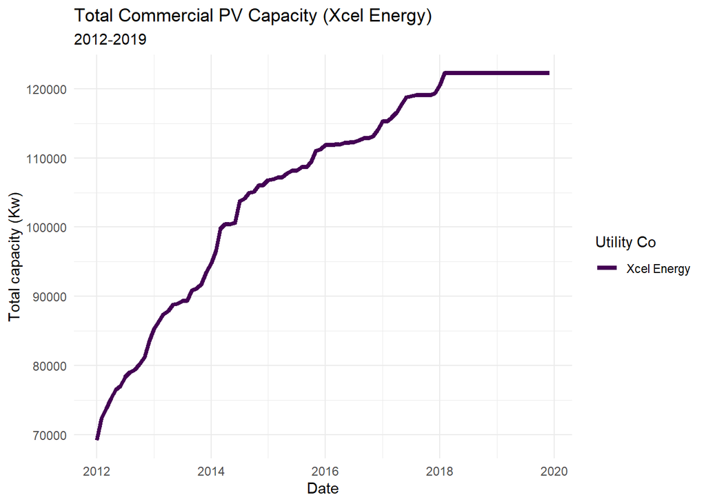

As with residential PV data commercial PV data for Xcel flat lines in 2018.

## Parting Thoughts

This exercise was meant to convey the broad trends of home PV in Colorado. In general capacity and the number of customers participating in these programs are rising. Customers opting into solar programs offered by utilities may be driving a lot of this increase in Colorado. I intend to do more research on these programs in the future. I would also like to figure out if customers opting into these programs are counted by the EIA in these data sets. There is also the Xcel issue of data flat lining. Xcel is the biggest utility (with respect to customers served) in Colorado so not having 2 years worth of their data is unfortunate. I am hoping to do a rough CBA on this within the next few weeks. Till then thanks for reading, feel free to use this or contact me with any questions. Thanks!